# OIF Model Projections

## Purpose

Explore changes in projected albacore fishery CPUE as a result of ocean iron fertilizatino (OIF). Based on fishery logbook and albacore species distribution model data, we designed and built a model to predict logbook CPUE in `fdms w cov.qmd`. Now, we take the selected model and project it under simulated, alternative albacore suitability scenarios resulting from OIF in the North Pacific.

## Load Data

The OIF scenarios have been processed into a list of prediction grids, one for each scenario. See `make_cov_proj_grid.R`

```r
pgl <- read_rds(here('data','predgrid_all_OIF_scenarios.rds'))
```

Here’s our fitted and selected `sdmTMB` model.

```r
m <- read_rds(here('output','alb_selected_model.rds'))
```

## Make projections

```r
projs <- imap(pgl,\(x,y) predict(m,newdata=x) |> mutate(scenario=y))
projdf <- bind_rows(projs)
```

## Mean CPUE Differences

What sort of comparisons do we want to make between the various iron fertilization scenarios and the baseline (historical) scenario? We could start by differencing them:

```r
# the baseline estimates are from scenario 1
# est is the model prediction (i.e., predicted log CPUE)
base_ests <- projs[[1]] |> select(est:est_rf) |>
  # exponentiate so the difference is made correctly?
  mutate(across(everything(),exp))
diffs <- imap(projs,\(x,y) {
  scen_ests <- x |>
    select(est:est_rf) |>
    mutate(across(everything(),exp))
  # subtract baseline estimates
  out <- scen_ests-base_ests
  out |>
    rename_with(~paste0("d_",.x),everything()) |>
    mutate(scenario=y)
})
diffdf <- bind_rows(diffs)

# projections with scenario diffs
scens_df <- projdf |>
  select(-scenario) |>
  bind_cols(diffdf) |>
  mutate(scenario=as.factor(scenario))
```

How big of potential differences are we talking here.

```r
# this is across all predicted grid cells and time steps
diffsumm <- scens_df |>
  mutate(expest=exp(est)) |>
  mutate(propdiff=d_est/expest) |>
  group_by(scenario) |>
  summarise(meandiff=mean(d_est),
            q05=as.numeric(quantile(d_est,0.05)),
            q95=as.numeric(quantile(d_est,0.90)),
            meanprop=mean(propdiff),.groups='drop',
            q05prop=as.numeric(quantile(propdiff,0.05)),
            q95prop=as.numeric(quantile(propdiff,0.90)))
knitr::kable(diffsumm,digits = 4)
```

| scenario | meandiff | q05 | q95 | meanprop | q05prop | q95prop |
| --- | --- | --- | --- | --- | --- | --- |
| 1 | 0.0000 | 0.0000 | 0.0000 | 0.0000 | 0.0000 | 0.0000 |
| 2 | -0.1316 | -0.8759 | 0.2317 | -0.0355 | -0.2400 | 0.0559 |
| 3 | -0.0349 | -0.4985 | 0.2105 | -0.0100 | -0.1231 | 0.0478 |
| 4 | -0.0684 | -0.6991 | 0.2549 | -0.0192 | -0.1872 | 0.0590 |
| 5 | -0.0062 | -0.3464 | 0.1957 | -0.0027 | -0.0817 | 0.0443 |
| 6 | -0.0036 | -0.3987 | 0.2440 | -0.0026 | -0.0947 | 0.0546 |
| 7 | 0.0098 | -0.1963 | 0.1548 | 0.0014 | -0.0475 | 0.0354 |
| 8 | 0.0101 | -0.1733 | 0.1403 | 0.0017 | -0.0423 | 0.0324 |

In general, it seems like the projected CPUE changes are within approximately -20% to 6%, across all time steps and grid cells. Here we can see that in smoothed histograms of the differences.

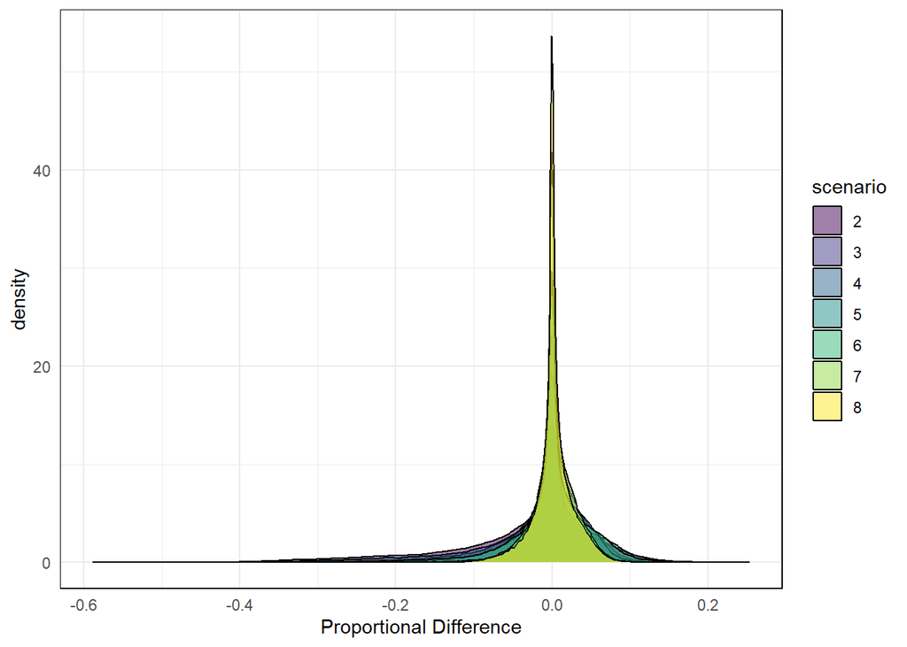

```r
p_props <- scens_df |>
  filter(scenario!="1") |>
  mutate(expest=exp(est)) |>
  mutate(propdiff=d_est/expest) |>
  ggplot(aes(propdiff,fill=scenario))+
  geom_density(alpha=0.5)+
  scale_fill_manual(values=viridis_pal()(7))+
  labs(x="Proportional Difference")
p_props
```

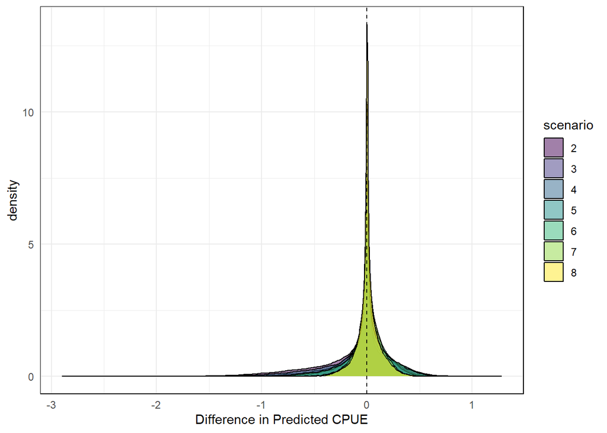

```r
p_diffs <- scens_df |>
  filter(scenario!="1") |>
  ggplot(aes(d_est,fill=scenario))+
  geom_density(alpha=0.5)+
  geom_vline(xintercept=0,linetype=2)+
  scale_fill_manual(values=viridis_pal()(7))+
  labs(x="Difference in Predicted CPUE")
p_diffs
```

```r
ggsave(here('plots','OIF scenarios CPUE diffs density.png'),p_diffs)
```

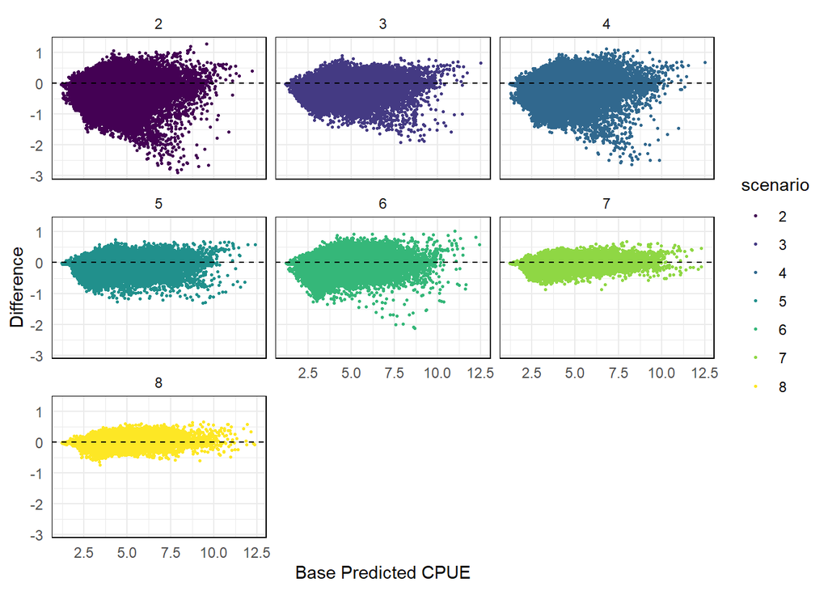

```r
p_diffs2 <- scens_df |>
  filter(scenario!=1) |>
  ggplot(aes(exp(est),d_est,color=scenario))+
  geom_point(size=0.5)+
  facet_wrap(~scenario)+
  scale_color_manual(values=viridis_pal()(7))+
  geom_hline(yintercept=0,linetype=2)+
  labs(x="Base Predicted CPUE",y="Difference")
p_diffs2
```

```r
ggsave(here('plots','OIF scenarios base vs diff.png'),p_diffs2,w=10)
```

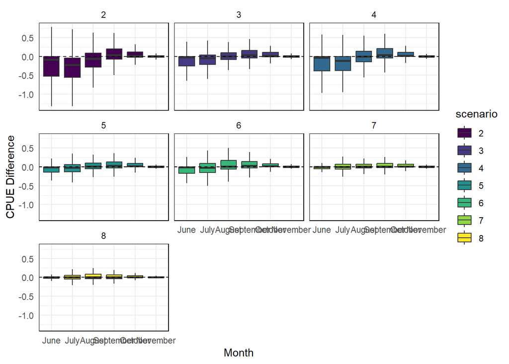

```r
pdiffs3 <- scens_df |>
  filter(scenario!="1") |>
  ggplot(aes(monthfct,d_est,fill=scenario))+
  geom_boxplot(outliers=F)+
  geom_hline(yintercept=0,linetype=2)+
  facet_wrap(~scenario)+
  scale_fill_manual(values=viridis_pal()(7))+
  labs(x="Month",y="CPUE Difference")
pdiffs3
```

```r
ggsave(here('plots','CPUE diff month OIF scenarios.png'),pdiffs3,w=10)
```

It sort of seems like across many OIF scenarios, predicted CPUE is lower in June/July and a bit higher in August/September, compared to the baseline scenario.

## Spatial Changes

How did spatial patterns of CPUE change in these different scenarios?

```r
quickmap <- function(dat, column = est) {
  ggplot()+
    geom_raster(data=dat, aes(Xkm, Ykm, fill = {{ column }})) +
    coord_fixed() +
    scale_fill_gradient2()+
    theme(panel.background=element_rect(fill='gray80'),
          panel.grid = element_blank())
}
```

Example of differences, for scenario 2 relative to baseline

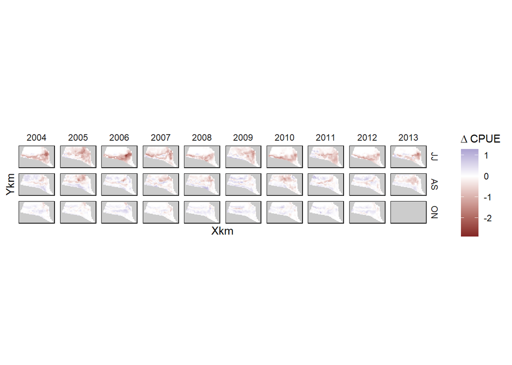

```r
p_s2 <- scens_df |>
  filter(scenario=="2",monthfct!="November") |>
  quickmap(d_est)+facet_grid(seasonfct~year)+
  labs(fill=expression(Delta ~ "CPUE"))+
  theme(axis.text=element_blank())
p_s2
```

```r
ggsave(here('plots','OIF scenario 2.png'),p_s2,w=10)
```

What if we looked at the mean difference and the variance among all scenarios.

```r
# calculate mean difference in each location
meandiff_df <- scens_df |>
  group_by(Xkm,Ykm,year,month,season,seasonfct,monthfct) |>
  # remove the null scenario
  filter(scenario!="1") |>
  mutate(expest=exp(est)) |>
  summarise(meandiff=mean(d_est),
            # relative to predicted CPUE
            propdiff=mean(d_est/expest),
            rangediff = max(d_est)-min(d_est),.groups='drop')
```

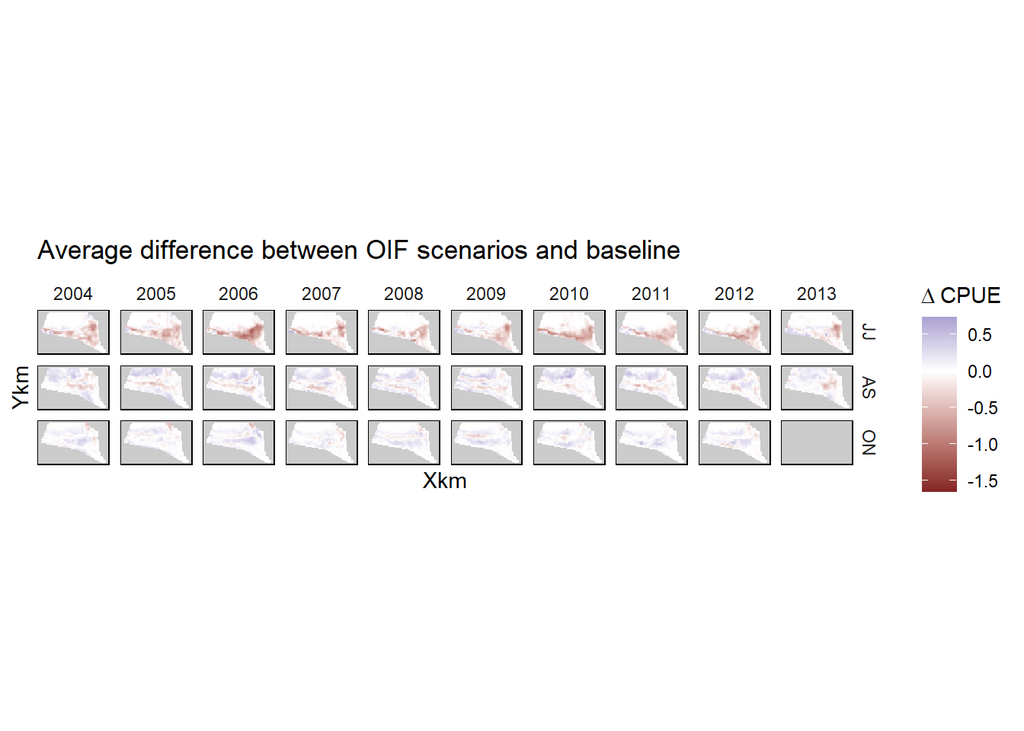

```r
p_meandiff <- meandiff_df |>
  quickmap(meandiff)+
  facet_grid(seasonfct~year)+
  theme(axis.text=element_blank())+
  labs(fill=expression(Delta ~ "CPUE"),title="Average difference between OIF scenarios and baseline")
p_rangediff <-meandiff_df |>
  quickmap(rangediff)+
  scale_fill_viridis(option="C")+
  facet_grid(seasonfct~year)+
  theme(axis.text=element_blank())+
  labs(fill=expression(Delta ~ "CPUE"),title="Range of outcomes across OIF scenarios")

p_propdiff <-meandiff_df |>
  quickmap(propdiff)+
  facet_grid(seasonfct~year)+
  theme(axis.text=element_blank())+
  labs(fill=expression(Delta ~ "CPUE"),title="Mean proportional change across OIF scenarios")
p_meandiff
```

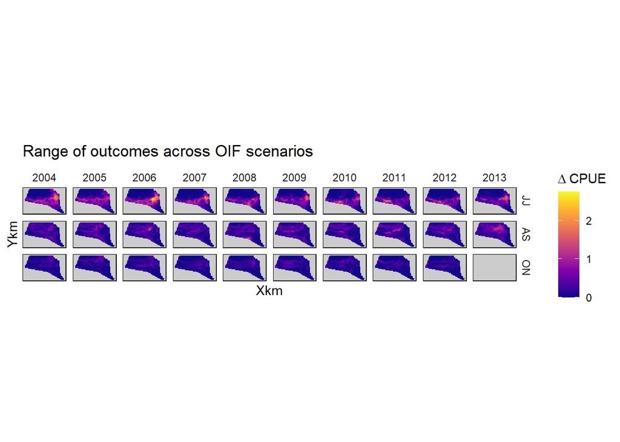

```r
p_rangediff
```

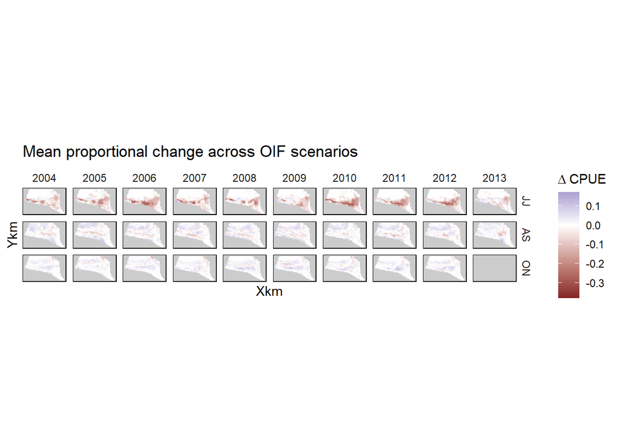

```r
p_propdiff
```

```r
ggsave(here('plots','OIF scenarios mean.png'),p_meandiff,w=10)
ggsave(here('plots','OIF scenarios range.png'),p_rangediff,w=10)
ggsave(here('plots','OIF scenarios proportions.png'),p_propdiff,w=10)
```